# QTM 150 Project

Camille O’Connell

December 10, 2018

# Are People Regionally Predisposed to Pronounce “Reese’s” a Certain Way?

[figure not shown]

### Research Motivations

##### This year as I embarked on my second collegiate trick-or-treating experience, (yes, I did in fact go trick-or-treating in a banana costume as a second-year student, **and** I didn’t even go alone) I was delightfully surprised by the sheer quantity of Reese’s peanut butter cups that I was receiving.

##### Before I continue on about Reese’s, the primary focus of this project, let me set the Halloween-night stage for you: Below is a lovely picture of my two pals and me standing in front of…wait for it…**an actual banana tree!** The home owner was ecstatic that two banana-clad people showed up, nevermind the fact that a group of college-aged students were his first visitors of the evening. He joked that we were his first harvests from the banana tree, which was kind of weird, but nonetheless a riveting experience to have as a 19 year old wearing a neon yellow banana suit.

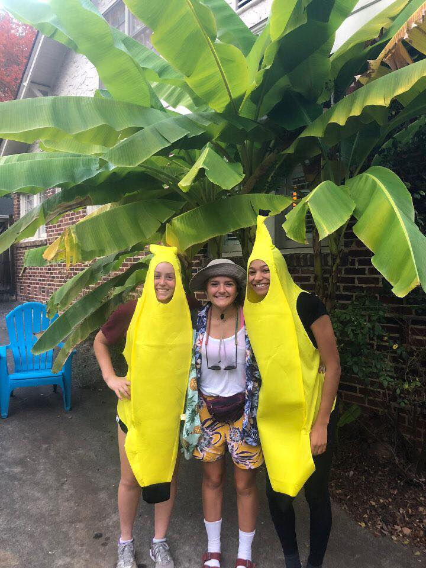

##### Now back to the main point: Reese’s candy. The peanut-butter-chocolate flavor combination of Reese’s products is perhaps the greatest medley of flavors to ever exist. However, for it’s insane popularity and place in American culture, it perplexes me just how differently people pronounce the candy’s name. I don’t think I would be wrong in saying that the nation stands divided in the pronunciation of this beloved candy. The candy, named after the founder Harry B. Reese, [is actually pronounced Rees-IS](https://www.thisisinsider.com/how-to-pronounce-reeses-2017-6), but people still argue with me about my **correct** pronunciation.

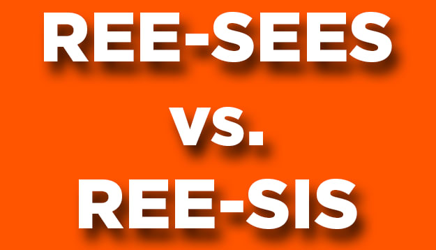

##### Having grown up on the West Coast, moving to the Northeast in high school, and now living in the South for college, I have heard many people attempt to convince me that my pronunciation is wrong. Many of the same people also pronounce “Reese’s” in isolation differently than they pronounce another version of the candy, “Reese’s Pieces”. In fact, they change the pronunciation of the word “pieces”, a very legitimate Enlgish word with only one accepted pronunciation, to rhyme with their alternate pronunciation of Reese’s. This bewilders me and on its own could be a whole separate project.

##### Back to the original point: I became interested in investigating the dichotomy of the pronunciation of Reese’s because of my trick-or-treating experience and also because of the concepts I have studied this semester in my linguistics class. Language change, and the study of sociolinguistics as a whole, has fascinated me and left me wondering what factors (age, region of upbringing, gender, socio-economic status, ethnicity, etc.) contribute to the differing pronunciation of words. The alternate pronunciation of “Reese’s” remains so popular that I wanted to conduct an experiment investigating whether or not there is a regional predisposition to favor one pronunciation over the other.

##### Before addressing any of the data, check out the time I tweeted at **Reese’s Puffs** and they responded to my tweet!

[figure not shown]

### Data Collection

##### In order to collect data, I created a simple Google survey with two data points: the US geographical region of the respondent and their favored pronunciation of “Reese’s”. I abided by the United States Census Bureau’s designation of the four statistical regions of the country: **Northeast, West, Midwest, and South**. I also included a [map](https://www2.census.gov/geo/pdfs/maps-data/maps/reference/us_regdiv.pdf) that grouped the states into their respective regions so that there was no ambiguity in determining which states belonged to which regions. For the pronunciation of “Reese’s” I gave two choices: **Rees-IS** or **Rees-EES**. Although these are not written in IPA, the international phonetic alphabet used by linguists, I felt as though these approaches most closely resembled the two pronunciations that I often hear for “Reese’s”. After I finished collecting my data, I exported the data as a `.csv` Excel file and uploaded the file to my GitHub account.

### Dataframe

##### Using the data gathered from the survey, four vectors are created and used to make a dataframe. First, the raw data (with row and column sums) is tabulated below.

```
##
##            Midwest Northeast South West Sum
##   Rees-EES      14        72    27   10 123
##   Rees-IS        9        48    29   43 129
##   Sum           23       120    56   53 252
```

##### The vectors are assigned and a dataframe is created.

```r
# Creates data frame from the vectors
pronounce_df <- data.frame(Midwest, Northeast, South, West)
pronounce_df
```

```
##          Midwest Northeast South West
## Rees-EES      14        72    27   10
## Rees-IS        9        48    29   43
```

### Visualizing the Data

##### Shown below is the general spread of the data. Most of the respondents are from the Northeast and the least amount of respondents are from the Midwest.

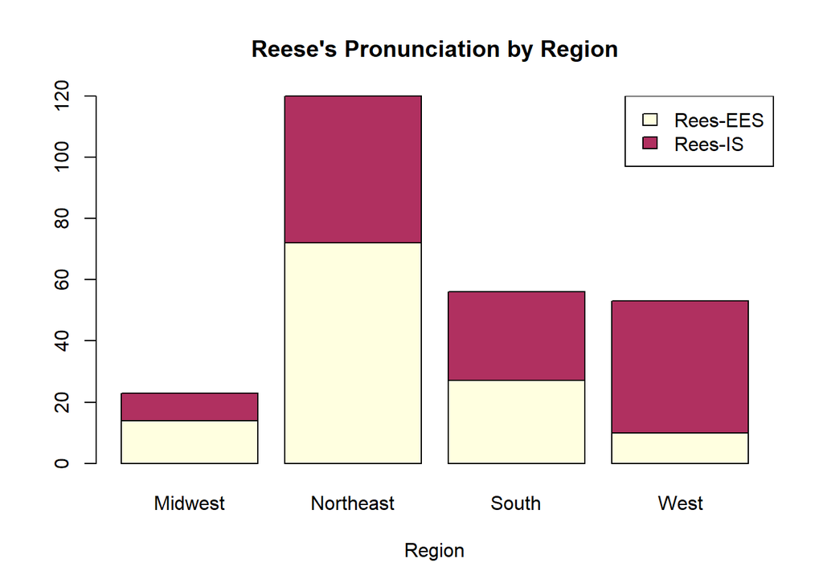

##### Pie charts for the nation as a whole and each individual region are created using the values from the data. In order to code for pie charts, I refered to [this](https://www.statmethods.net/graphs/pie.html) website.

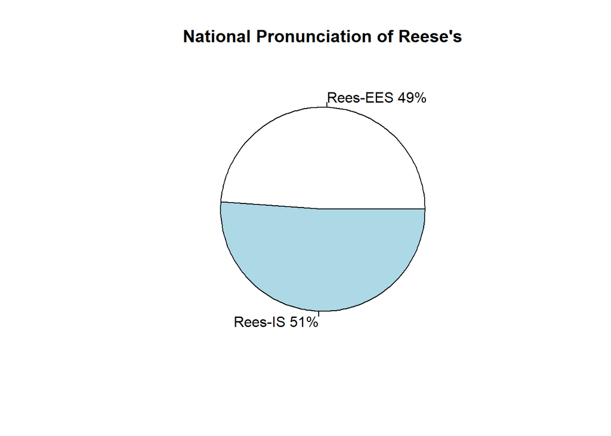

##### The nation (represented by the 252 survey respondents) is nearly divided half-and-half in the pronunciation of “Reese’s”. There is no favored pronunciation nationally.

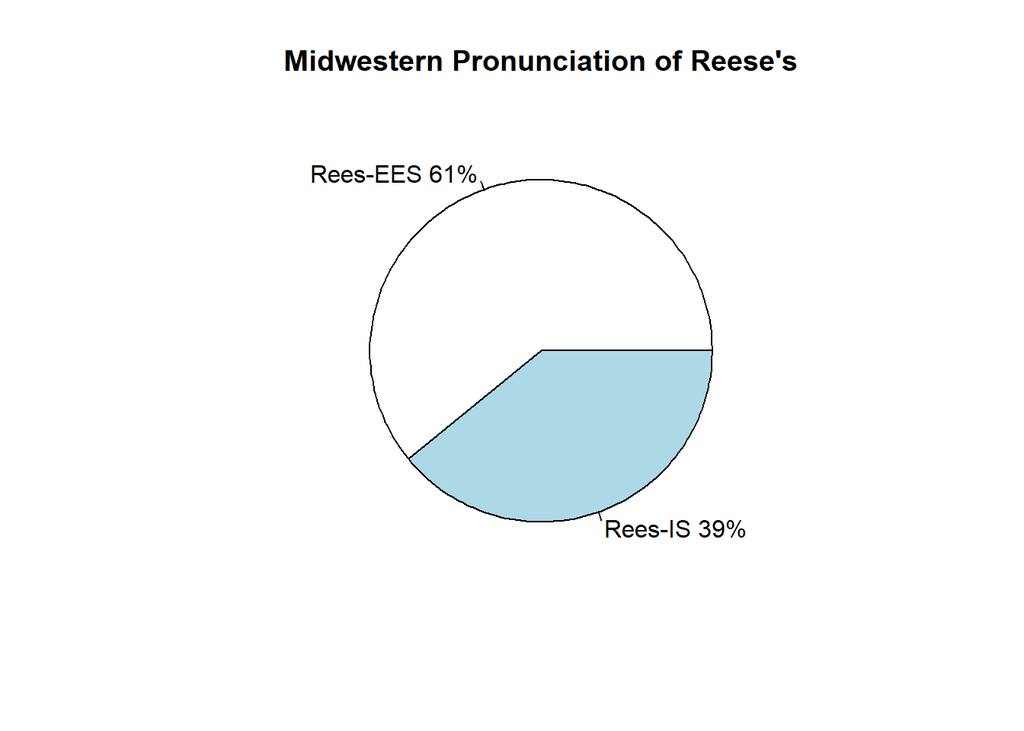

##### Among Midwesterners, there is a slight preference for the Rees-EES pronunciation.

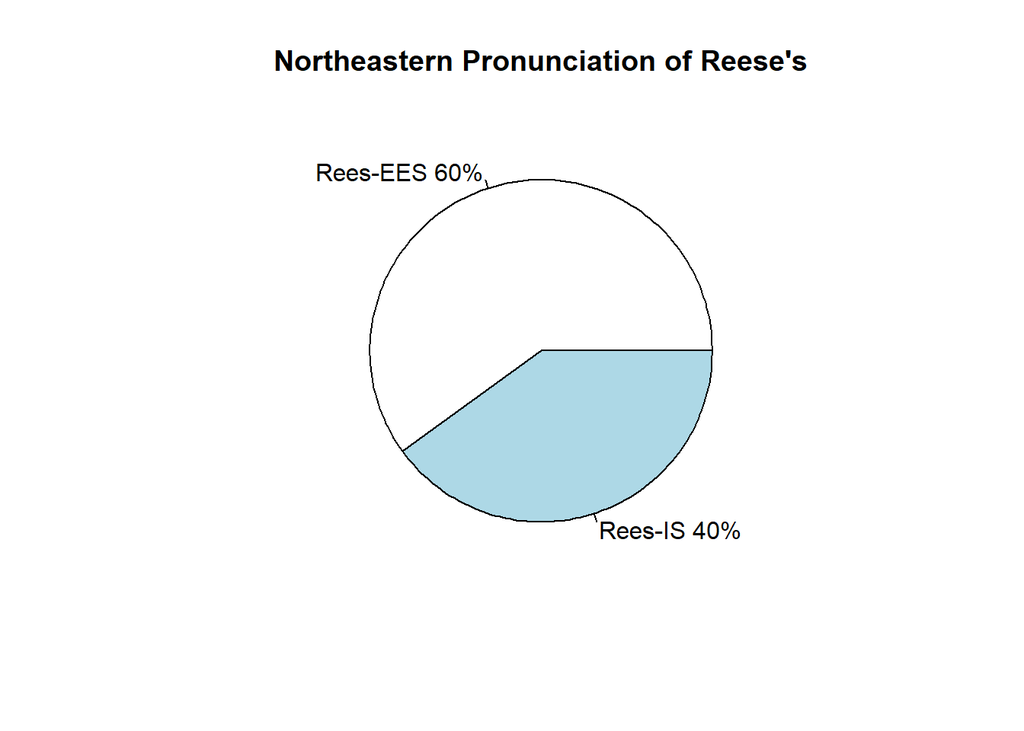

##### Among Northeasterners, there is a slight preference for the Rees-EES pronunciation.

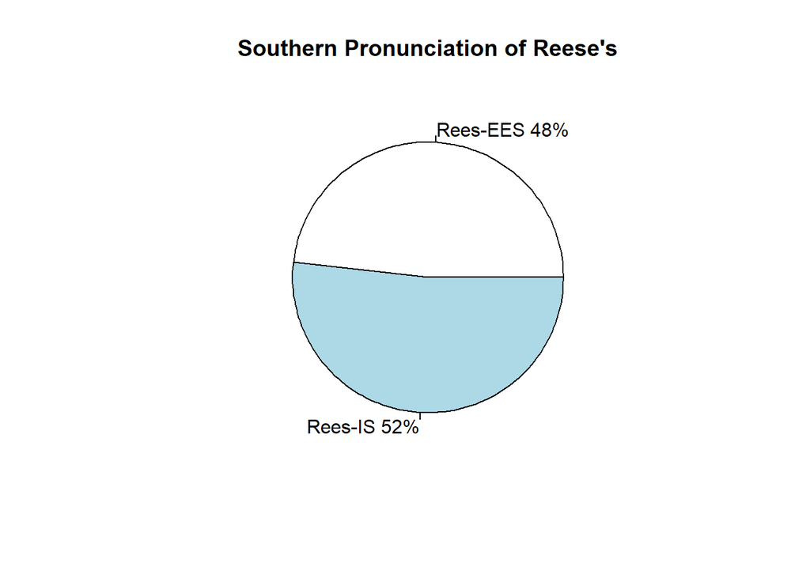

##### Among Southerns, there is no clear preference for one pronunciation over the other.

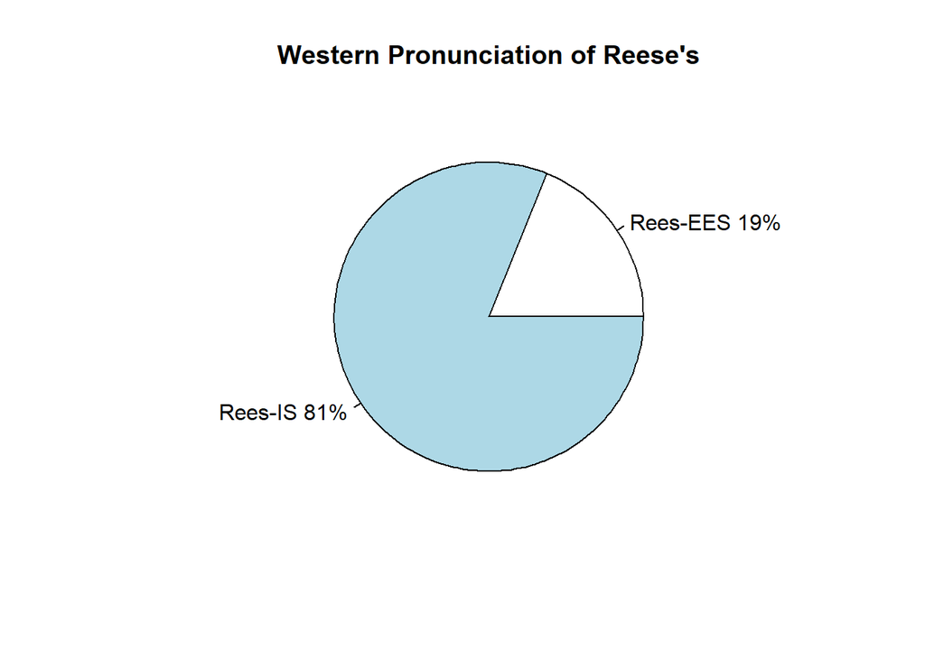

##### Among Westerners, there is a strong preference for “Rees-IS”.

### Chi-Square Test of Independence

##### Since we are dealing with two factor variables, a chi-square test of independence can check for a statistically significant association between the region and pronunciation. If the results are significant at the 95% confidence interval, there is an association between the region a person identifies with and their pronunciation of “Reese’s”.

#### Chi-Square Test Assumptions:

- **Independent Observations**?
  - yes!
- **Simple Random-Sampling**?
  - yes!
- **Expected Frequency Count >5**?
  - need to check

##### Below, the expected frequencies for each cell is computed using the command `Ins.Comp.test`. The expected frequency counts are computed separately for each level of “region” at each level of “pronunciation”.

```
##
##             Midwest Northeast    South     West
##   Rees-EES 11.22619  58.57143 27.33333 25.86905
##   Rees-IS  11.77381  61.42857 28.66667 27.13095
```

##### Since all of the assumptions are satisfied, we can proceed with the chi-square test. The null and alternative hypotheses are defined below.

#### Hypotheses:

$H_0:$ Region and pronunciation are independent (not associated).

$H_a:$ Region and pronunciation are not independent (associated).

##### The Chi-sqaure test is run using the command `chisq.test`, and the results are shown below. Check out that p-value!

```
##
##  Pearson's Chi-squared test
##
## data:  table
## X-squared = 26.378, df = 3, p-value = 7.95e-06
```

#### Frequency Table:

##### The table below displays the proportion of people from each of the regions who use a certain pronunciation.

```
##
##              Rees-EES   Rees-IS
##   Midwest   0.6086957 0.3913043
##   Northeast 0.6000000 0.4000000
##   South     0.4821429 0.5178571
##   West      0.1886792 0.8113208
```

### Interpretation of Results

##### The p-value is less than 0.05, in fact it is significantly less than 0.05 at 7.95e-06, therefore the null hypothesis is rejected. This means that there is a statistically significant association between the region and pronunciation of “Reese’s”. People from the Northeast are more susceptible to saying Rees-EES, people from the Midwest favor Rees-EES, people from the South have no apparent preference, and people from the West strongly favor the Rees-IS pronunciation. These results suggest that there may be a regional predisposition to favor one pronunciation of “Reese’s” over the other.

### Limitations

##### I was able to get a large sample size, 252 survey respondents to be exact, which I was not expecting. Luckily, I was able to get enough respondents from all regions to ensure that I could run a chi-sqaure test.

##### What was a limiting factor were the choices of pronunciation, Rees-IS or Rees-EES. Personally, I know people who fluctuate between the pronunciations, but I did not deem it necessary for the sake of this simple research project to create a third level, “either”. In the future, though, this would be something worthwhile to investigate. Also, just because someone is from a certain region does not necessarily mean that they are predisposed to a certain pronunciation. There are many other unaccounted for factors that may contribute to their salient pronunciation.

##### Another limitation were the levels of the factor variable, region. Some of the respondents noted that they felt that their state did not belong to the given pre-determined region. Also, many people have lived in many different states and even countries, so there is the consideration of how well a certain person represents the larger populaiton of people from that region.